# 002 incidence

Katie Gostic

11/1/2017

Notes on data formatting from Deborah Wentworth:

- symdur is symptom duration (days) prior to enrollment
- date info is for enrollment date
- fluvac6 and fluvac12 are flu vaccination in last 6 or last 12 months
- anyvac combines values from fluvac6 and fluvac12, whichever was collected for a given patient is reported.
- anyav is use of antivirals at any time
- anydx is any diagnosis in the medical history section
- flutype is subtype: 1=H1N1, 2=H3N2, 3=flu B, 4=PCR negative, 5=Inf A, subtype unknown, and 6=coinfection with multiple strains
- resolved is symptom resolution within 14 days
- country code is the 3 letter code for country of enrollment - think the abbreviations will be obvious

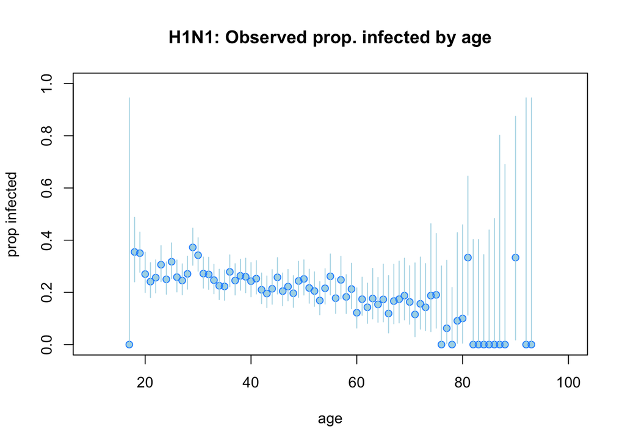

#### Visualize the relationship between age and prob of H3N2 infection

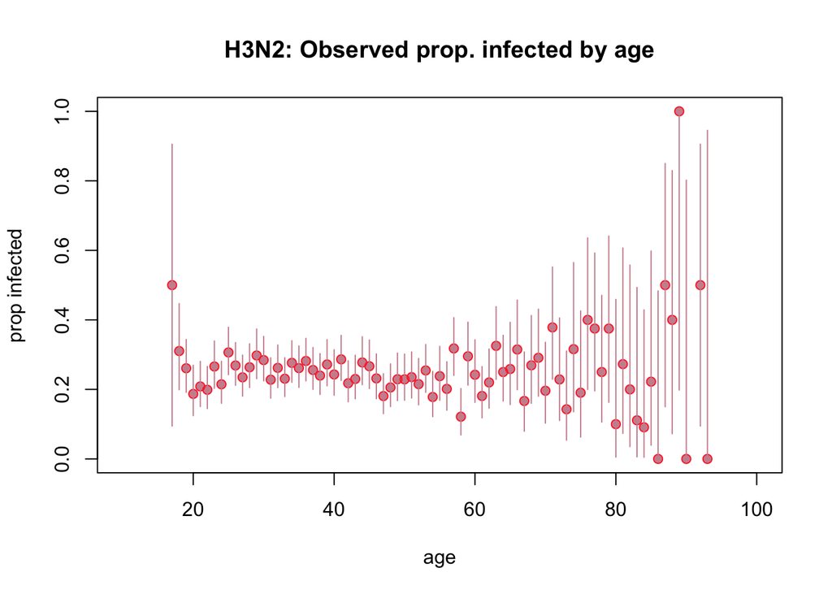

#### Visualize the relationship between country and prob infection

H1N1

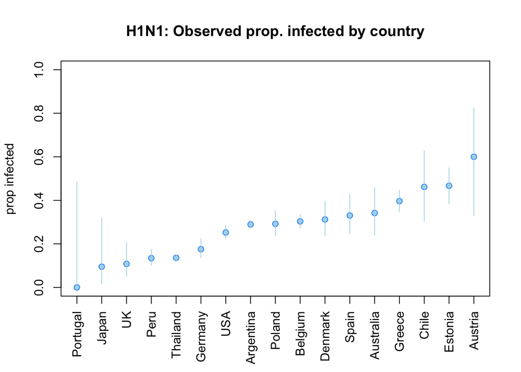

H3N2

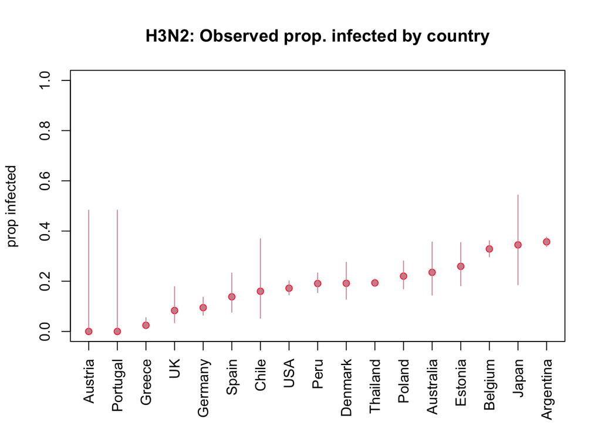

#### Visualize the relationship between season and prob infection

H1N1

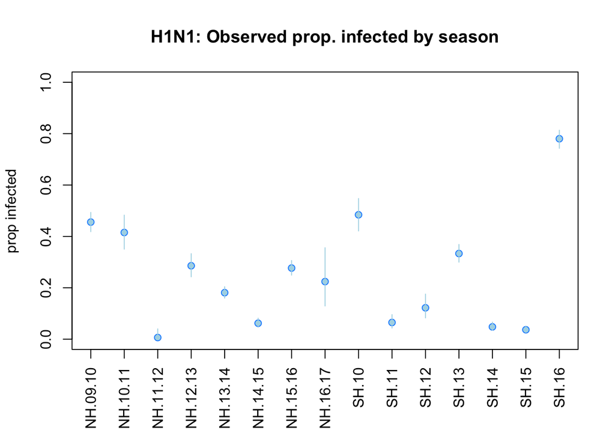

H3N2

[figure not shown]

- age
- imprinting status
- vaccination status
- antiviral use
- season
- country

### Clean data for fitting

```
##
## Argentina Australia   Austria   Belgium     Chile   Denmark   Estonia
##      2277        79        15       820        39       141       150
##   Germany    Greece     Japan      Peru    Poland  Portugal     Spain
##       313       395        21       387       250         6       112
##  Thailand        UK       USA
##      2510        74       817
```

```
## [1] 8406
```

```
##
## Argentina Australia   Austria   Belgium     Chile   Denmark   Estonia
##      2516        68         6       851        25       120       108
##   Germany    Greece     Japan      Peru    Poland  Portugal     Spain
##       285       244        29       414       227         6        87
##  Thailand        UK       USA
##      2689        72       738
```

```
## [1] 8485
```

### First fit a model where the only independent variable is age

Treat vaccination, antivial use, underlying symptoms, country and season as blocking variables with fixed effects

```r
library(splines)
library(ROCR)
```

```r
## Fit to country, season and medical history only (no effect of age or imprinting)
fit0 = glm(infected ~ anyav + anydx + country + H3.valid*season + H3.valid*anyvac, data = train, family = binomial)
summary(fit0)
```

```
##
## Call:
## glm(formula = infected ~ anyav + anydx + country + H3.valid *
##     season + H3.valid * anyvac, family = binomial, data = train)
##
## Deviance Residuals:
##     Min       1Q   Median       3Q      Max
## -2.0650  -0.7259  -0.4551  -0.0004   3.1212
##
## Coefficients:
##                           Estimate Std. Error z value Pr(>|z|)
## (Intercept)                0.35434    0.22330   1.587 0.112542
## anyav1                     0.93970    0.12666   7.419 1.18e-13 ***
## anydx1                    -0.29473    0.07793  -3.782 0.000156 ***
## countryAustralia           0.05223    0.35429   0.147 0.882805
## countryBelgium             0.13864    0.17968   0.772 0.440348
## countryChile               2.57799    0.86622   2.976 0.002919 **
## countryDenmark            -0.94021    0.35112  -2.678 0.007412 **
## countryEstonia            -0.07407    0.30172  -0.245 0.806082
## countryGermany            -0.92701    0.25758  -3.599 0.000320 ***
## countryGreece             -0.31021    0.23331  -1.330 0.183651
## countryJapan               0.10942    1.14241   0.096 0.923697
## countryOther              -0.55311    0.52857  -1.046 0.295362
## countryPeru               -0.86040    0.19665  -4.375 1.21e-05 ***
## countryPoland             -0.34491    0.26607  -1.296 0.194867
## countrySpain              -0.54182    0.31382  -1.727 0.084254 .
## countryThailand           -0.70870    0.12988  -5.457 4.85e-08 ***
## countryUK                 -1.46956    0.50549  -2.907 0.003647 **
## countryUSA                -0.33379    0.18914  -1.765 0.077604 .
## H3.valid1                -16.36746  207.91489  -0.079 0.937254
## seasonNH.10.11            -0.67659    0.31322  -2.160 0.030764 *
## seasonNH.11.12           -16.64374  307.30621  -0.054 0.956808
## seasonNH.12.13            -0.76466    0.25577  -2.990 0.002793 **
## seasonNH.13.14            -1.12252    0.21423  -5.240 1.61e-07 ***
## seasonNH.14.15            -2.53542    0.34299  -7.392 1.45e-13 ***
## seasonNH.15.16            -0.79081    0.20425  -3.872 0.000108 ***
## seasonNH.16.17            -0.23470    0.54577  -0.430 0.667170
## seasonSH.10               -0.22966    0.34539  -0.665 0.506090
## seasonSH.11               -3.74801    0.55915  -6.703 2.04e-11 ***
## seasonSH.12               -1.73915    0.39415  -4.412 1.02e-05 ***
```

[output cut: 17 more lines]

```
## H3.valid1:seasonSH.14     18.91975  207.91534   0.091 0.927495
## H3.valid1:seasonSH.15     18.80571  207.91522   0.090 0.927930
## H3.valid1:seasonSH.16     15.28103  207.91514   0.073 0.941411
## H3.valid1:anyvac1          0.56178    0.17635   3.186 0.001444 **
## H3.valid1:anyvac2         -1.96914    1.31559  -1.497 0.134453
## ---
## Signif. codes:  0 '***' 0.001 '**' 0.01 '*' 0.05 '.' 0.1 ' ' 1
##
## (Dispersion parameter for binomial family taken to be 1)
##
##     Null deviance: 5813.7  on 5440  degrees of freedom
## Residual deviance: 4819.0  on 5390  degrees of freedom
## AIC: 4921
##
## Number of Fisher Scoring iterations: 15
```

```r
## H1N1 fit to age only, plus fixed effects of vaccination, av use, underlying conditions, country and season
fit1 = glm(infected ~ anyav + anydx + country + age + H3.valid*season + H3.valid*anyvac, data = train, family = binomial)
summary(fit1)
```

```
##
## Call:
## glm(formula = infected ~ anyav + anydx + country + age + H3.valid *
##     season + H3.valid * anyvac, family = binomial, data = train)
##
## Deviance Residuals:
##      Min        1Q    Median        3Q       Max
## -2.08431  -0.72150  -0.45733  -0.00041   3.10480
##
## Coefficients:
##                            Estimate Std. Error z value Pr(>|z|)
## (Intercept)                0.592989   0.297474   1.993 0.046216 *
## anyav1                     0.937612   0.126650   7.403 1.33e-13 ***
## anydx1                    -0.282060   0.078651  -3.586 0.000335 ***
## countryAustralia           0.050759   0.354414   0.143 0.886116
## countryBelgium             0.147031   0.179866   0.817 0.413674
## countryChile               2.569584   0.867121   2.963 0.003043 **
## countryDenmark            -0.932310   0.351678  -2.651 0.008025 **
## countryEstonia            -0.095171   0.302331  -0.315 0.752920
## countryGermany            -0.932568   0.257615  -3.620 0.000295 ***
## countryGreece             -0.306327   0.233387  -1.313 0.189343
## countryJapan               0.130874   1.140198   0.115 0.908618
## countryOther              -0.571851   0.530227  -1.079 0.280810
## countryPeru               -0.852284   0.196663  -4.334 1.47e-05 ***
## countryPoland             -0.336326   0.266212  -1.263 0.206454
## countrySpain              -0.531495   0.313882  -1.693 0.090399 .
## countryThailand           -0.705987   0.129909  -5.434 5.50e-08 ***
## countryUK                 -1.478592   0.505716  -2.924 0.003458 **
## countryUSA                -0.324521   0.189275  -1.715 0.086428 .
## age                       -0.005497   0.004525  -1.215 0.224479
## H3.valid1                -16.360725 207.983649  -0.079 0.937300
## seasonNH.10.11            -0.663774   0.313506  -2.117 0.034238 *
## seasonNH.11.12           -16.627451 307.336660  -0.054 0.956854
## seasonNH.12.13            -0.748220   0.256251  -2.920 0.003502 **
## seasonNH.13.14            -1.098353   0.215143  -5.105 3.30e-07 ***
## seasonNH.14.15            -2.512026   0.343560  -7.312 2.64e-13 ***
## seasonNH.15.16            -0.763753   0.205477  -3.717 0.000202 ***
## seasonNH.16.17            -0.203603   0.545892  -0.373 0.709168
## seasonSH.10               -0.220973   0.345433  -0.640 0.522368
## seasonSH.11               -3.728001   0.559235  -6.666 2.62e-11 ***
```

[output cut: 18 more lines]

```
## H3.valid1:seasonSH.14     18.911316 207.984099   0.091 0.927551
## H3.valid1:seasonSH.15     18.801612 207.983985   0.090 0.927970
## H3.valid1:seasonSH.16     15.275178 207.983898   0.073 0.941453
## H3.valid1:anyvac1          0.558484   0.176285   3.168 0.001534 **
## H3.valid1:anyvac2         -1.974041   1.318547  -1.497 0.134358
## ---
## Signif. codes:  0 '***' 0.001 '**' 0.01 '*' 0.05 '.' 0.1 ' ' 1
##
## (Dispersion parameter for binomial family taken to be 1)
##
##     Null deviance: 5813.7  on 5440  degrees of freedom
## Residual deviance: 4817.5  on 5389  degrees of freedom
## AIC: 4921.5
##
## Number of Fisher Scoring iterations: 15
```

```r
## H1N1 fit to age plus imprinting, plus fixed effects of vaccination, av use, underlying conditions, country and season
fit2 = glm(infected ~ anyav + anydx + country + age + imp.status + H3.valid*season + H3.valid*anyvac, data = train, family = binomial)
summary(fit2)
```

```
##
## Call:
## glm(formula = infected ~ anyav + anydx + country + age + imp.status +
##     H3.valid * season + H3.valid * anyvac, family = binomial,
##     data = train)
##
## Deviance Residuals:
##      Min        1Q    Median        3Q       Max
## -2.09618  -0.72325  -0.45609  -0.00041   3.09311
##
## Coefficients:
##                            Estimate Std. Error z value Pr(>|z|)
## (Intercept)                0.588849   0.297507   1.979 0.047785 *
## anyav1                     0.937981   0.126669   7.405 1.31e-13 ***
## anydx1                    -0.280844   0.078676  -3.570 0.000357 ***
## countryAustralia           0.047615   0.354619   0.134 0.893189
## countryBelgium             0.145781   0.179892   0.810 0.417723
## countryChile               2.566142   0.868431   2.955 0.003128 **
## countryDenmark            -0.932916   0.351648  -2.653 0.007978 **
## countryEstonia            -0.103233   0.302634  -0.341 0.733016
## countryGermany            -0.938422   0.257759  -3.641 0.000272 ***
## countryGreece             -0.310154   0.233558  -1.328 0.184193
## countryJapan               0.141648   1.139301   0.124 0.901055
## countryOther              -0.570886   0.529913  -1.077 0.281337
## countryPeru               -0.856004   0.196769  -4.350 1.36e-05 ***
## countryPoland             -0.336140   0.266251  -1.262 0.206772
## countrySpain              -0.534009   0.313673  -1.702 0.088673 .
## countryThailand           -0.708637   0.129968  -5.452 4.97e-08 ***
## countryUK                 -1.480105   0.505668  -2.927 0.003422 **
## countryUSA                -0.327784   0.189352  -1.731 0.083437 .
## age                       -0.005954   0.004570  -1.303 0.192691
## imp.statuslow              0.052203   0.072606   0.719 0.472148
## H3.valid1                -16.359751 207.965283  -0.079 0.937298
## seasonNH.10.11            -0.660459   0.313712  -2.105 0.035265 *
## seasonNH.11.12           -16.626674 307.337585  -0.054 0.956856
## seasonNH.12.13            -0.748666   0.256424  -2.920 0.003504 **
## seasonNH.13.14            -1.095074   0.215208  -5.088 3.61e-07 ***
## seasonNH.14.15            -2.514111   0.343619  -7.317 2.54e-13 ***
## seasonNH.15.16            -0.765704   0.205560  -3.725 0.000195 ***
## seasonNH.16.17            -0.203555   0.546008  -0.373 0.709292
```

[output cut: 20 more lines]

```
## H3.valid1:seasonSH.14     18.905420 207.965733   0.091 0.927567
## H3.valid1:seasonSH.15     18.800556 207.965619   0.090 0.927968
## H3.valid1:seasonSH.16     15.280889 207.965532   0.073 0.941426
## H3.valid1:anyvac1          0.550619   0.176595   3.118 0.001821 **
## H3.valid1:anyvac2         -1.980584   1.319487  -1.501 0.133349
## ---
## Signif. codes:  0 '***' 0.001 '**' 0.01 '*' 0.05 '.' 0.1 ' ' 1
##
## (Dispersion parameter for binomial family taken to be 1)
##
##     Null deviance: 5813.7  on 5440  degrees of freedom
## Residual deviance: 4817.0  on 5388  degrees of freedom
## AIC: 4923
##
## Number of Fisher Scoring iterations: 15
```

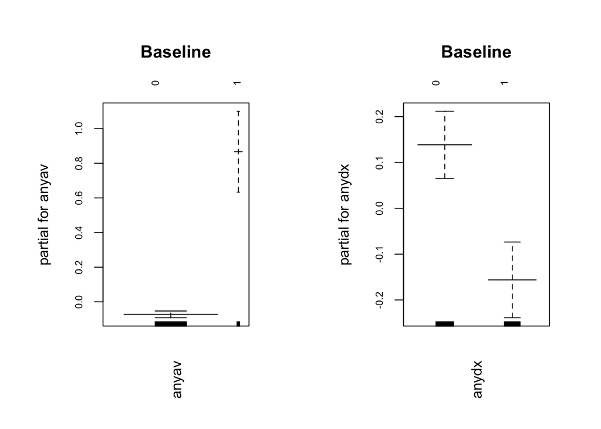

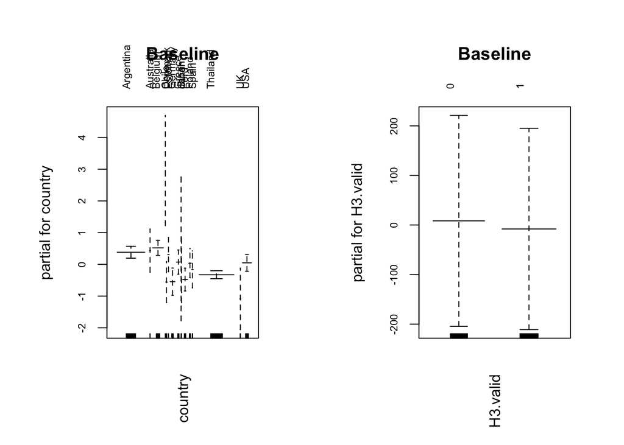

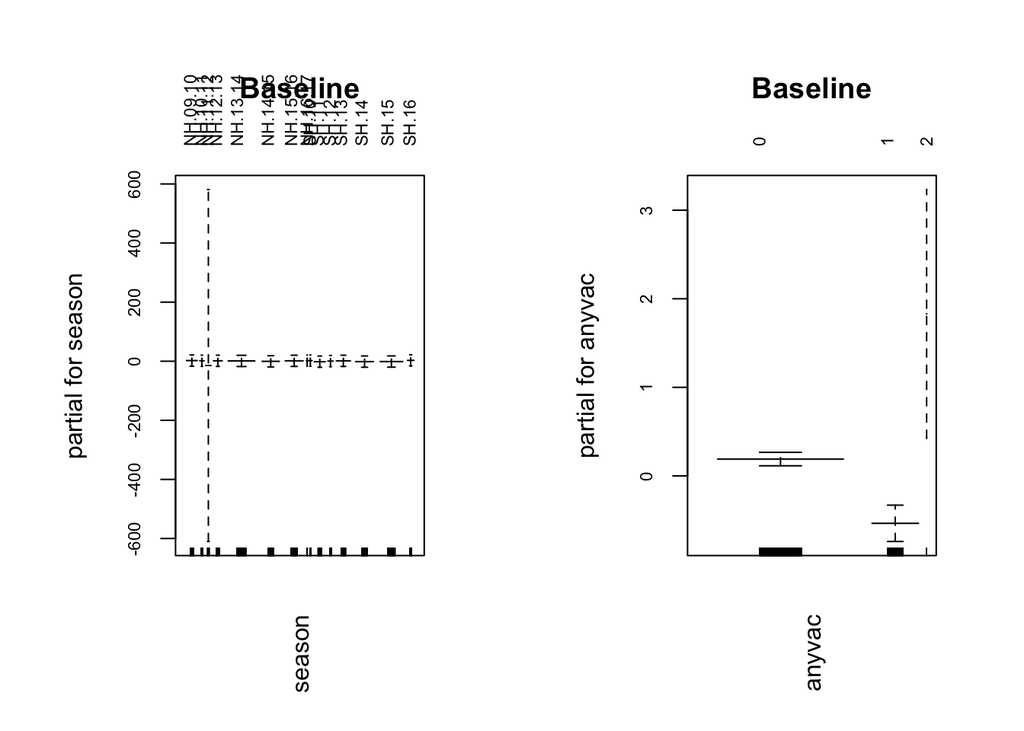

```r
## Plot the fits for each model side by side
par(mfrow = c(1, 2), las = 3, mar = c(6, 6, 6, 3), cex.axis = .7)
library(gam)
plot.gam(fit0, se = T, col = 'darkslateblue', main = 'Baseline')
```

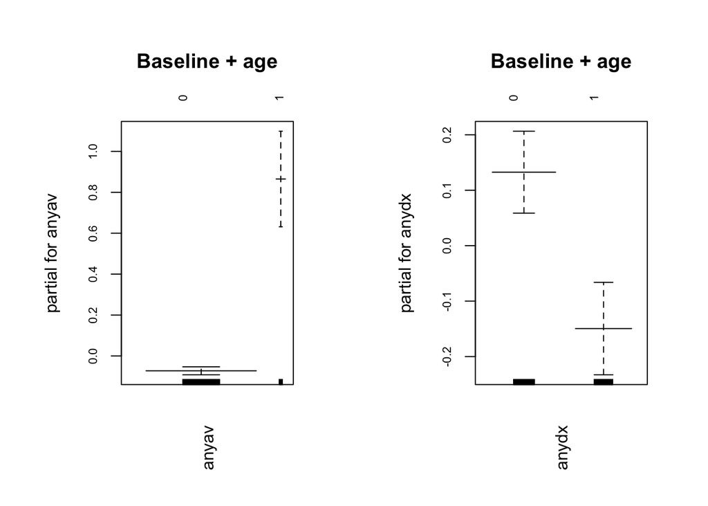

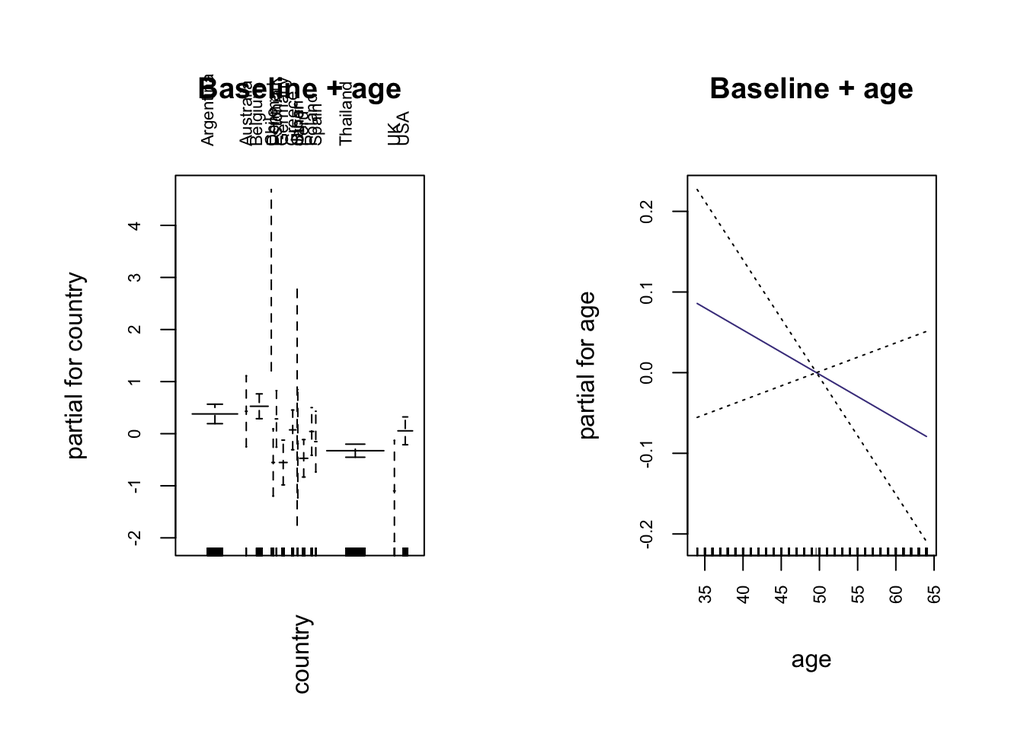

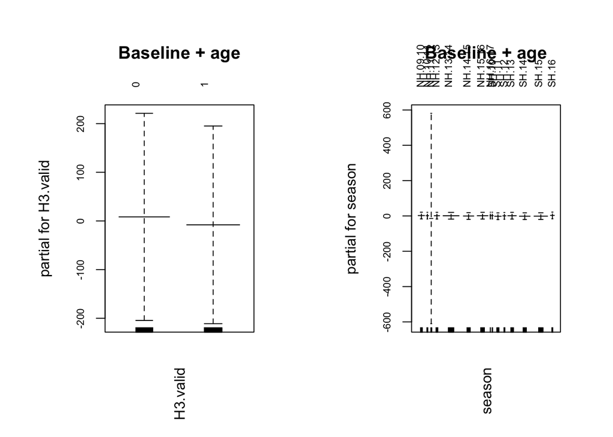

```r
plot.gam(fit1, se = T, col = 'darkslateblue', main = 'Baseline + age')
```

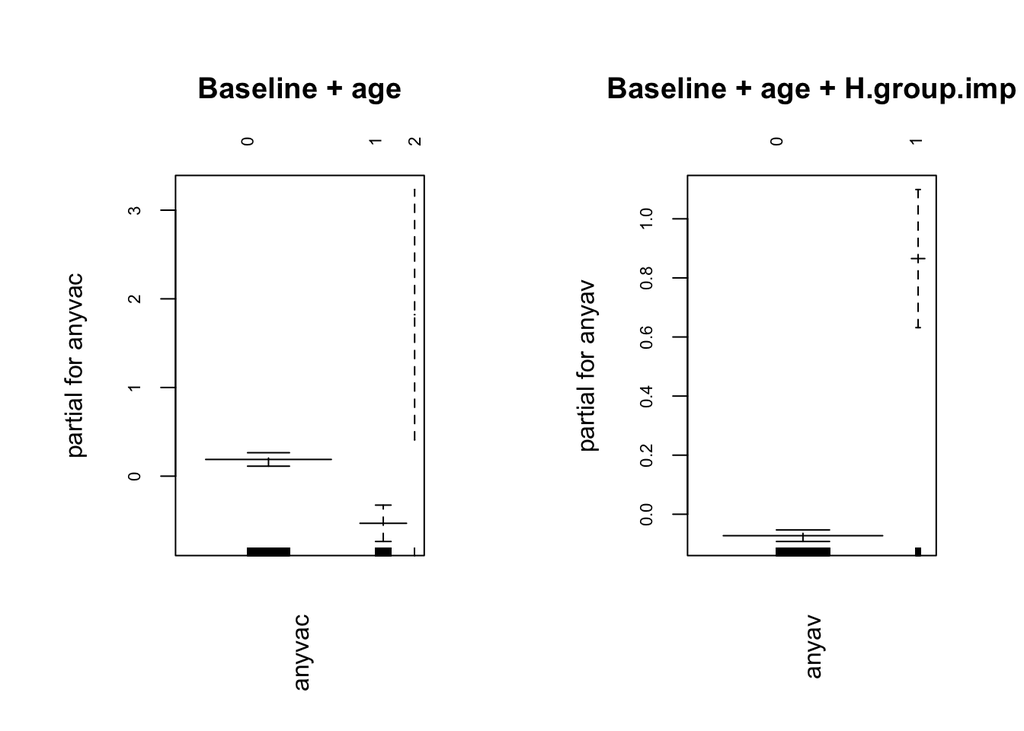

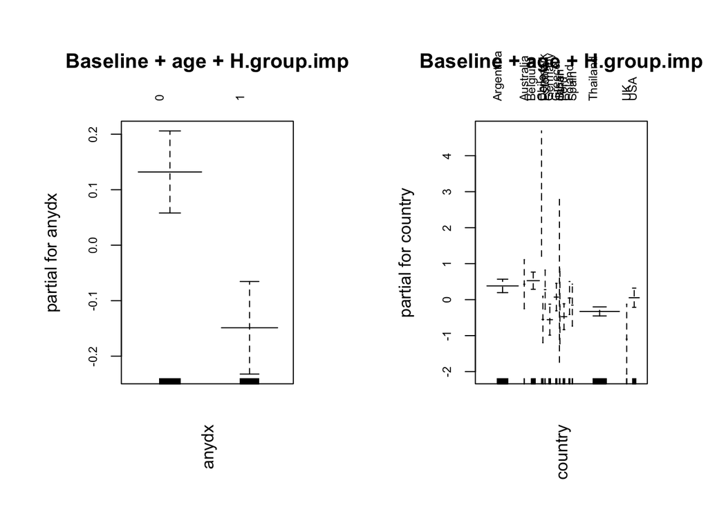

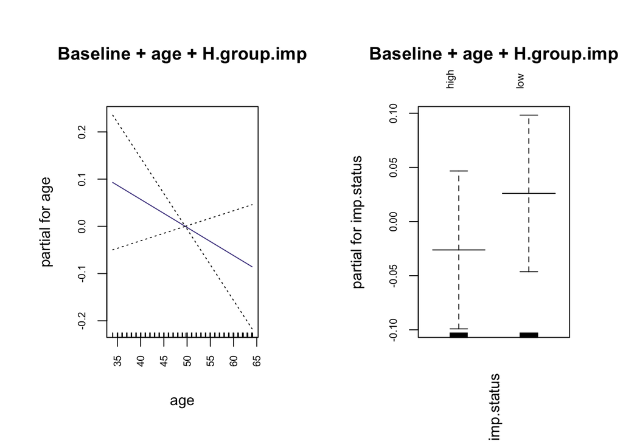

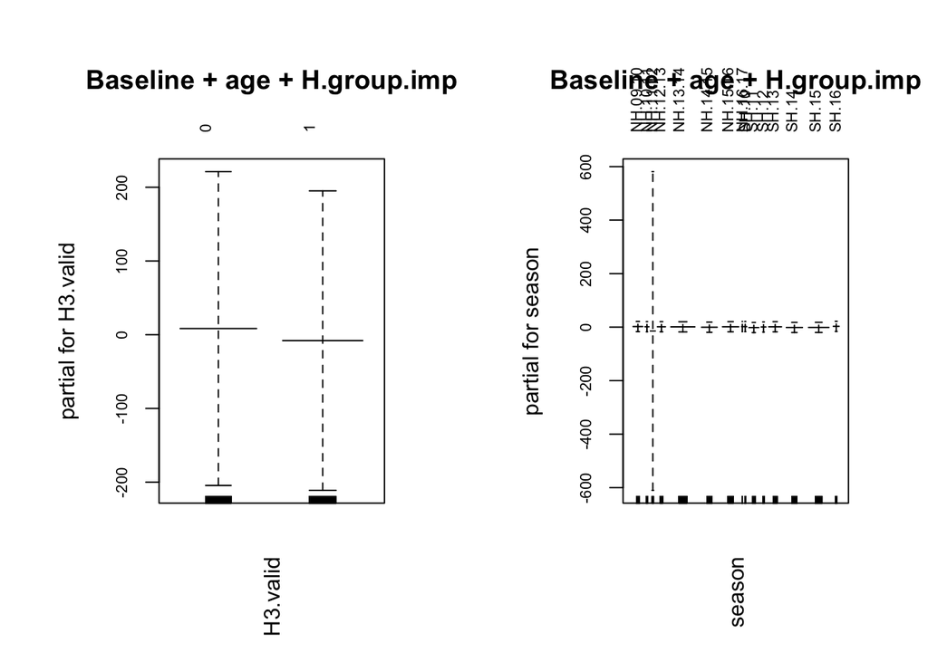

```r
plot.gam(fit2, se = T, col = 'darkslateblue', main = 'Baseline + age + H.group.imp')
```

```r
# plot.gam(fit3, se = T, col = 'darkslateblue', main = 'Baseline + age + H.subtype.imp')
# plot.gam(fit4, se = T, col = 'darkslateblue', main = 'Baseline + age + N.subtype.imp')
pdf('002Incidence_constrained.pdf')
plot.gam(fit2, se = T, col = 'darkslateblue', main = 'Baseline + age + imp')
dev.off()
```

[figure not shown]

```r
## Test performance on test data
# Predict probs for each patient
probs0 = predict(fit0, newdata = test, type = 'response')
probs1 = predict(fit1, newdata = test, type = 'response')
probs2 = predict(fit2, newdata = test, type = 'response')
# probs3 = predict(fit3, newdata = test, type = 'response')
# probs4 = predict(fit4, newdata = test, type = 'response')

# Create a predict object
pr0 = prediction(probs0, test$infected)
pr1 = prediction(probs1, test$infected)
pr2 = prediction(probs2, test$infected)
# pr3 = prediction(probs3, test$infected)
# pr4 = prediction(probs4, test$infected)

# Assess tp and fp
prf0 = performance(pr0, measure = 'tpr', x.measure = 'fpr')
prf1 = performance(pr1, measure = 'tpr', x.measure = 'fpr')
prf2 = performance(pr2, measure = 'tpr', x.measure = 'fpr')
# prf3 = performance(pr3, measure = 'tpr', x.measure = 'fpr')
# prf4 = performance(pr4, measure = 'tpr', x.measure = 'fpr')

# Calculate AUCs
auc = sapply(list(pr0, pr1, pr2), FUN = function(xx){aa = performance(xx, measure = 'auc')
                                                                      round(aa@y.values[[1]], 3) })

# Plot AUC
par(mfrow = c(1,1))
```

[figure not shown]

```r
plot(prf0, lwd = 2, col = cols[3])
plot(prf1, col = cols[2], add = TRUE, lwd = 2)
plot(prf2, col = cols[1], add = TRUE, lwd = 2)
# plot(prf3, col = 'limegreen', add = TRUE, lwd = 2)
# plot(prf4, col = 'magenta', add = TRUE, lwd = 2)
abline(a = 0, b = 1, lty = 2)
legend('bottomright', paste(c('baseline                  AUC = ', 'baseline+age          AUC = ', 'baseline+age+imp  AUC = ', 'baseline+age+sub  AUC =', 'baseline+age+N     AUC = '), auc), col = c(cols[3:1], 'limegreen', 'magenta'),  lty = 1)
```

```r
pdf('002Incidence_AUC_constrained.pdf')
par(lwd = 3.5, cex = 1.5, cex.axis = 1.5, cex.lab = 1.5)
# Plot AUC
par(mfrow = c(1,1))
plot(prf0, lwd = 2, col = cols[3])
plot(prf1, col = cols[2], add = TRUE, lwd = 2)
plot(prf2, col = cols[1], add = TRUE, lwd = 2)
# plot(prf3, col = 'limegreen', add = TRUE, lwd = 2)
# plot(prf4, col = 'magenta', add = TRUE, lwd = 2)
abline(a = 0, b = 1, lty = 2)
legend('bottomright', paste(c('baseline                  AUC = ', 'baseline+age          AUC = ', 'baseline+age+imp  AUC = ', 'baseline+age+sub  AUC =', 'baseline+age+N     AUC = '), auc), col = c(cols[3:1], 'limegreen', 'magenta'),  lty = 1)
dev.off()
```

```r
# Calculate AUC for test data
AIC = c(fit0$aic, fit1$aic, fit2$aic); names(AIC) =  c('baseline', 'baseline+age', 'baseline+age+imp')
del.AIC = sort(AIC - min(AIC))
del.AIC
```

```
##         baseline     baseline+age baseline+age+imp
##         0.000000         0.522958         2.005920
```

```r
#
# load('master.AIC.table.constrained.RData')
# master.AIC.table['002Incidence', c('baseline', 'baseline+age', 'baseline+age+imp', 'baseline+age+sub', 'baseline+age+N')] = AIC - min(AIC)
# save(master.AIC.table, file = 'master.AIC.table.constrained.RData')
# rm(master.AIC.table)
```